# Risk Factor Analysis

## Outcome Variable

**Outcome Variable:** swasted

## Predictor Variables

**Intervention Variable:** single

**Adjustment Set:**

- arm
- W_mage
- meducyrs
- feducyrs
- W_mhtcm
- W_mwtkg
- W_mbmi
- delta_W_mage
- delta_meducyrs
- delta_feducyrs
- delta_W_mhtcm
- delta_W_mwtkg
- delta_W_mbmi

## Stratifying Variables

The analysis was stratified on these variable(s):

- agecat
- studyid
- country

## Data Summary

| agecat | studyid | country | single | swasted | n_cell | n |
| --- | --- | --- | --- | --- | --- | --- |
| Birth | COHORTS | GUATEMALA | 0 | 0 | 602 | 691 |
| Birth | COHORTS | GUATEMALA | 0 | 1 | 52 | 691 |
| Birth | COHORTS | GUATEMALA | 1 | 0 | 35 | 691 |
| Birth | COHORTS | GUATEMALA | 1 | 1 | 2 | 691 |
| Birth | COHORTS | INDIA | 0 | 0 | 4242 | 4463 |
| Birth | COHORTS | INDIA | 0 | 1 | 214 | 4463 |
| Birth | COHORTS | INDIA | 1 | 0 | 7 | 4463 |
| Birth | COHORTS | INDIA | 1 | 1 | 0 | 4463 |
| Birth | COHORTS | PHILIPPINES | 0 | 0 | 2674 | 2860 |
| Birth | COHORTS | PHILIPPINES | 0 | 1 | 115 | 2860 |
| Birth | COHORTS | PHILIPPINES | 1 | 0 | 66 | 2860 |
| Birth | COHORTS | PHILIPPINES | 1 | 1 | 5 | 2860 |
| Birth | JiVitA-4 | BANGLADESH | 0 | 0 | 2357 | 2393 |
| Birth | JiVitA-4 | BANGLADESH | 0 | 1 | 31 | 2393 |
| Birth | JiVitA-4 | BANGLADESH | 1 | 0 | 5 | 2393 |
| Birth | JiVitA-4 | BANGLADESH | 1 | 1 | 0 | 2393 |
| Birth | MAL-ED | BANGLADESH | 0 | 0 | 207 | 215 |
| Birth | MAL-ED | BANGLADESH | 0 | 1 | 8 | 215 |
| Birth | MAL-ED | BANGLADESH | 1 | 0 | 0 | 215 |
| Birth | MAL-ED | BANGLADESH | 1 | 1 | 0 | 215 |
| Birth | MAL-ED | BRAZIL | 0 | 0 | 54 | 62 |
| Birth | MAL-ED | BRAZIL | 0 | 1 | 0 | 62 |
| Birth | MAL-ED | BRAZIL | 1 | 0 | 8 | 62 |
| Birth | MAL-ED | BRAZIL | 1 | 1 | 0 | 62 |
| Birth | MAL-ED | INDIA | 0 | 0 | 45 | 45 |
| Birth | MAL-ED | INDIA | 0 | 1 | 0 | 45 |
| Birth | MAL-ED | INDIA | 1 | 0 | 0 | 45 |
| Birth | MAL-ED | INDIA | 1 | 1 | 0 | 45 |
| Birth | MAL-ED | NEPAL | 0 | 0 | 25 | 26 |
| Birth | MAL-ED | NEPAL | 0 | 1 | 1 | 26 |

[output cut: 138 more lines]

The following strata were considered:

- agecat: 24 months, studyid: COHORTS, country: GUATEMALA
- agecat: 24 months, studyid: COHORTS, country: INDIA
- agecat: 24 months, studyid: COHORTS, country: PHILIPPINES
- agecat: 24 months, studyid: JiVitA-4, country: BANGLADESH
- agecat: 24 months, studyid: MAL-ED, country: BANGLADESH
- agecat: 24 months, studyid: MAL-ED, country: BRAZIL
- agecat: 24 months, studyid: MAL-ED, country: INDIA
- agecat: 24 months, studyid: MAL-ED, country: NEPAL
- agecat: 24 months, studyid: MAL-ED, country: PERU
- agecat: 24 months, studyid: MAL-ED, country: SOUTH AFRICA
- agecat: 24 months, studyid: MAL-ED, country: TANZANIA, UNITED REPUBLIC OF
- agecat: 24 months, studyid: PROBIT, country: BELARUS
- agecat: 24 months, studyid: TanzaniaChild2, country: TANZANIA, UNITED REPUBLIC OF
- agecat: 24 months, studyid: ZVITAMBO, country: ZIMBABWE
- agecat: 6 months, studyid: COHORTS, country: GUATEMALA
- agecat: 6 months, studyid: COHORTS, country: INDIA
- agecat: 6 months, studyid: COHORTS, country: PHILIPPINES
- agecat: 6 months, studyid: Guatemala BSC, country: GUATEMALA
- agecat: 6 months, studyid: JiVitA-4, country: BANGLADESH
- agecat: 6 months, studyid: MAL-ED, country: BANGLADESH
- agecat: 6 months, studyid: MAL-ED, country: BRAZIL
- agecat: 6 months, studyid: MAL-ED, country: INDIA
- agecat: 6 months, studyid: MAL-ED, country: NEPAL
- agecat: 6 months, studyid: MAL-ED, country: PERU
- agecat: 6 months, studyid: MAL-ED, country: SOUTH AFRICA
- agecat: 6 months, studyid: MAL-ED, country: TANZANIA, UNITED REPUBLIC OF
- agecat: 6 months, studyid: PROBIT, country: BELARUS
- agecat: 6 months, studyid: TanzaniaChild2, country: TANZANIA, UNITED REPUBLIC OF
- agecat: 6 months, studyid: ZVITAMBO, country: ZIMBABWE
- agecat: Birth, studyid: COHORTS, country: GUATEMALA
- agecat: Birth, studyid: COHORTS, country: INDIA
- agecat: Birth, studyid: COHORTS, country: PHILIPPINES
- agecat: Birth, studyid: JiVitA-4, country: BANGLADESH
- agecat: Birth, studyid: MAL-ED, country: BANGLADESH
- agecat: Birth, studyid: MAL-ED, country: BRAZIL
- agecat: Birth, studyid: MAL-ED, country: INDIA
- agecat: Birth, studyid: MAL-ED, country: NEPAL
- agecat: Birth, studyid: MAL-ED, country: PERU
- agecat: Birth, studyid: MAL-ED, country: SOUTH AFRICA
- agecat: Birth, studyid: MAL-ED, country: TANZANIA, UNITED REPUBLIC OF
- agecat: Birth, studyid: PROBIT, country: BELARUS
- agecat: Birth, studyid: ZVITAMBO, country: ZIMBABWE

### Dropped Strata

Some strata were dropped due to rare outcomes:

- agecat: Birth, studyid: COHORTS, country: GUATEMALA
- agecat: Birth, studyid: COHORTS, country: INDIA
- agecat: Birth, studyid: JiVitA-4, country: BANGLADESH
- agecat: Birth, studyid: MAL-ED, country: BANGLADESH
- agecat: Birth, studyid: MAL-ED, country: BRAZIL
- agecat: Birth, studyid: MAL-ED, country: INDIA
- agecat: Birth, studyid: MAL-ED, country: NEPAL
- agecat: Birth, studyid: MAL-ED, country: PERU
- agecat: Birth, studyid: MAL-ED, country: SOUTH AFRICA
- agecat: Birth, studyid: MAL-ED, country: TANZANIA, UNITED REPUBLIC OF
- agecat: 6 months, studyid: COHORTS, country: GUATEMALA
- agecat: 6 months, studyid: COHORTS, country: INDIA
- agecat: 6 months, studyid: COHORTS, country: PHILIPPINES
- agecat: 6 months, studyid: Guatemala BSC, country: GUATEMALA
- agecat: 6 months, studyid: JiVitA-4, country: BANGLADESH
- agecat: 6 months, studyid: MAL-ED, country: BANGLADESH
- agecat: 6 months, studyid: MAL-ED, country: BRAZIL
- agecat: 6 months, studyid: MAL-ED, country: INDIA
- agecat: 6 months, studyid: MAL-ED, country: NEPAL
- agecat: 6 months, studyid: MAL-ED, country: PERU
- agecat: 6 months, studyid: MAL-ED, country: SOUTH AFRICA
- agecat: 6 months, studyid: MAL-ED, country: TANZANIA, UNITED REPUBLIC OF
- agecat: 6 months, studyid: PROBIT, country: BELARUS
- agecat: 6 months, studyid: TanzaniaChild2, country: TANZANIA, UNITED REPUBLIC OF
- agecat: 24 months, studyid: COHORTS, country: GUATEMALA
- agecat: 24 months, studyid: COHORTS, country: INDIA
- agecat: 24 months, studyid: COHORTS, country: PHILIPPINES
- agecat: 24 months, studyid: JiVitA-4, country: BANGLADESH
- agecat: 24 months, studyid: MAL-ED, country: BANGLADESH
- agecat: 24 months, studyid: MAL-ED, country: BRAZIL
- agecat: 24 months, studyid: MAL-ED, country: INDIA
- agecat: 24 months, studyid: MAL-ED, country: NEPAL
- agecat: 24 months, studyid: MAL-ED, country: PERU
- agecat: 24 months, studyid: MAL-ED, country: SOUTH AFRICA
- agecat: 24 months, studyid: MAL-ED, country: TANZANIA, UNITED REPUBLIC OF
- agecat: 24 months, studyid: PROBIT, country: BELARUS
- agecat: 24 months, studyid: TanzaniaChild2, country: TANZANIA, UNITED REPUBLIC OF
- agecat: 24 months, studyid: ZVITAMBO, country: ZIMBABWE

## Methods Detail

We’re interested in the causal parameters $E[Y_a]$ for all values of $a \in \mathcal{A}$. These parameters represent the mean outcome if, possibly contrary to fact, we intervened to set all units to have $A=a$. Under the randomization and positivity assumptions, these are identified by the statistical parameters $\psi_a=E_W[E_{Y|A,W}(Y|A=a,W)]$. In addition, we’re interested in the mean of $Y$, $E[Y]$ under no intervention (the observed mean). We will estimate these parameters by using SuperLearner to fit the relevant likelihood factors – $E_{Y|A,W}(Y|A=a,W)$ and $p(A=a|W)$, and then updating our likelihood fit using a joint TMLE.

For unadjusted analyses ($W=\{\}$), initial likelihoods were estimated using Lrnr_glm to estimate the simple $E(Y|A)$ and Lrnr_mean to estimate $p(A)$. For adjusted analyses, a small library containing Lrnr_glmnet, Lrnr_xgboost, and Lrnr_mean was used.

Having estimated these parameters, we will then use the delta method to estimate relative risks and attributable risks relative to a prespecified baseline level of $A$.

# Results Detail

## Results Plots

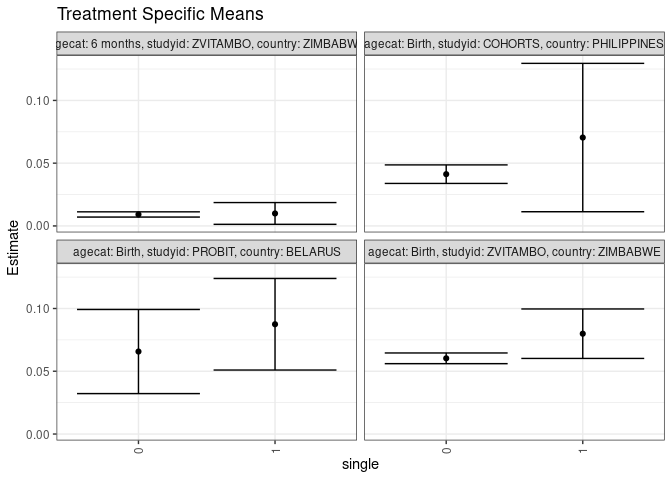

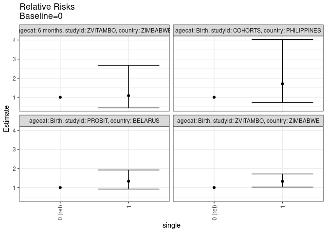

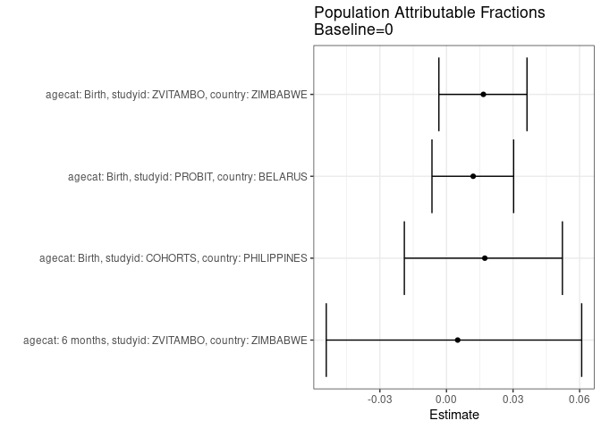

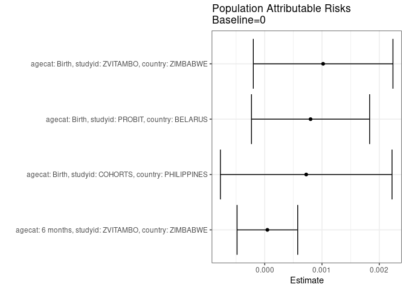

## Results Table

### Parameter: TSM

| agecat | studyid | country | intervention_level | baseline_level | estimate | ci_lower | ci_upper |
| --- | --- | --- | --- | --- | --- | --- | --- |
| Birth | COHORTS | PHILIPPINES | 0 | NA | 0.0412334 | 0.0338517 | 0.0486152 |
| Birth | COHORTS | PHILIPPINES | 1 | NA | 0.0704225 | 0.0113146 | 0.1295305 |
| Birth | PROBIT | BELARUS | 0 | NA | 0.0657118 | 0.0322031 | 0.0992206 |
| Birth | PROBIT | BELARUS | 1 | NA | 0.0874501 | 0.0509676 | 0.1239326 |
| Birth | ZVITAMBO | ZIMBABWE | 0 | NA | 0.0603139 | 0.0560539 | 0.0645740 |
| Birth | ZVITAMBO | ZIMBABWE | 1 | NA | 0.0799179 | 0.0602207 | 0.0996152 |
| 6 months | ZVITAMBO | ZIMBABWE | 0 | NA | 0.0091582 | 0.0070669 | 0.0112495 |
| 6 months | ZVITAMBO | ZIMBABWE | 1 | NA | 0.0099404 | 0.0012703 | 0.0186104 |

### Parameter: E(Y)

| agecat | studyid | country | intervention_level | baseline_level | estimate | ci_lower | ci_upper |
| --- | --- | --- | --- | --- | --- | --- | --- |
| Birth | COHORTS | PHILIPPINES | NA | NA | 0.0419580 | 0.0346088 | 0.0493073 |
| Birth | PROBIT | BELARUS | NA | NA | 0.0665123 | 0.0333611 | 0.0996634 |
| Birth | ZVITAMBO | ZIMBABWE | NA | NA | 0.0613340 | 0.0571874 | 0.0654805 |
| 6 months | ZVITAMBO | ZIMBABWE | NA | NA | 0.0092046 | 0.0071712 | 0.0112380 |

### Parameter: RR

| agecat | studyid | country | intervention_level | baseline_level | estimate | ci_lower | ci_upper |
| --- | --- | --- | --- | --- | --- | --- | --- |
| Birth | COHORTS | PHILIPPINES | 0 | 0 | 1.000000 | 1.0000000 | 1.000000 |
| Birth | COHORTS | PHILIPPINES | 1 | 0 | 1.707900 | 0.7240114 | 4.028833 |
| Birth | PROBIT | BELARUS | 0 | 0 | 1.000000 | 1.0000000 | 1.000000 |
| Birth | PROBIT | BELARUS | 1 | 0 | 1.330812 | 0.9223471 | 1.920166 |
| Birth | ZVITAMBO | ZIMBABWE | 0 | 0 | 1.000000 | 1.0000000 | 1.000000 |
| Birth | ZVITAMBO | ZIMBABWE | 1 | 0 | 1.325033 | 1.0253478 | 1.712310 |
| 6 months | ZVITAMBO | ZIMBABWE | 0 | 0 | 1.000000 | 1.0000000 | 1.000000 |
| 6 months | ZVITAMBO | ZIMBABWE | 1 | 0 | 1.085405 | 0.4405852 | 2.673954 |

### Parameter: PAR

| agecat | studyid | country | intervention_level | baseline_level | estimate | ci_lower | ci_upper |
| --- | --- | --- | --- | --- | --- | --- | --- |
| Birth | COHORTS | PHILIPPINES | 0 | NA | 0.0007246 | -0.0007738 | 0.0022231 |
| Birth | PROBIT | BELARUS | 0 | NA | 0.0008004 | -0.0002311 | 0.0018320 |
| Birth | ZVITAMBO | ZIMBABWE | 0 | NA | 0.0010200 | -0.0001992 | 0.0022392 |
| 6 months | ZVITAMBO | ZIMBABWE | 0 | NA | 0.0000464 | -0.0004830 | 0.0005758 |

### Parameter: PAF

| agecat | studyid | country | intervention_level | baseline_level | estimate | ci_lower | ci_upper |
| --- | --- | --- | --- | --- | --- | --- | --- |
| Birth | COHORTS | PHILIPPINES | 0 | NA | 0.0172702 | -0.0189809 | 0.0522317 |
| Birth | PROBIT | BELARUS | 0 | NA | 0.0120342 | -0.0065352 | 0.0302610 |
| Birth | ZVITAMBO | ZIMBABWE | 0 | NA | 0.0166309 | -0.0034214 | 0.0362825 |
| 6 months | ZVITAMBO | ZIMBABWE | 0 | NA | 0.0050439 | -0.0541556 | 0.0609189 |